# *Mycobacterium tuberculosis* WGS and cluster analysis

Author

RutiSeq-nf

Published

August 7, 2025

This interactive report provides key summary results to support the verification of your RutiSeq analysis and to flag any samples that may be unsuitable for inclusion in clustering (these can be excluded, and the analysis re-run if necessary). Samples of concern are clearly highlighted for your review. All data tables used to generate the figures are available in the `results/tables` directory of the RutiSeq output. This report is most effective for datasets containing more than 100 samples.

## Database Summary

This section summarizes the entire RutiSeq-db collection along with the most recently analyzed cases. It provides an overview of the lineages of the cases, resistance profiles, and identifies any isolates that failed to meet the minimum quality metrics. These failed isolates have been excluded from the clustering analysis.

### Sequencing

In this section the raw sequence data is summarised with respect to current and past sequencing libraries.

**Total Reads**

In this tab the total number of WGS reads are summarised by libraries. The newest libraries are colored in red.

[interactive chart not shown]

**Cases over time**

[interactive chart not shown]

**Cumilative cases**

[interactive chart not shown]

### Newest cases: default_run

**0 genome(s) failed the minimum quality criteria** (see `Parameters`) and should be reviewed, and **0 genomes were identified as mixed infection(s)** (i.e., containing multiple lineages). These are highlighted in the `Failed QC` tab.

**Main lineages**

[interactive chart not shown]

**Sub-lineages**

[interactive chart not shown]

**DRTypes (WHO)**

[interactive chart not shown]

**Resistance (WHO)**

[interactive chart not shown]

**Failed QC**

If this table is empty, then great! All your new samples passed the quality metrics defined when you ran the RutiSeq workflow. Any failed variables will be colored in red.

|  | Sample | Total Reads | Unambiguous Total Bases (%) | Unambiguous Coverage median | Infection type | Lineages (fractions) |
| --- | --- | --- | --- | --- | --- | --- |

**SNP freq (main)**

This tab features a ridge plot displaying multiple histograms that show the number of SNP variations identified between isolates belonging to each lineage and the reference genome (H37Rv). For clarity, isolate identified as a mixed infection have been removed.

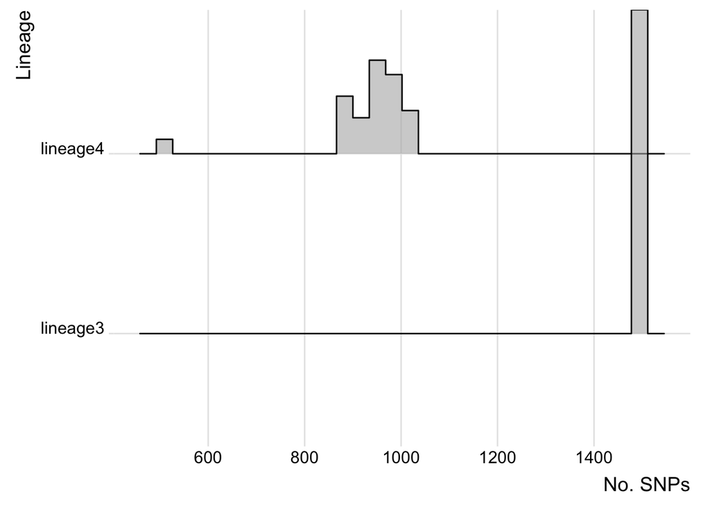

**SNP freq (sub)**

This tab features a ridge plot displaying multiple histograms that show the number of SNP variations identified between isolates belonging to each lineage and the reference genome (H37Rv). For clarity, isolate identified as a mixed infection have been removed.

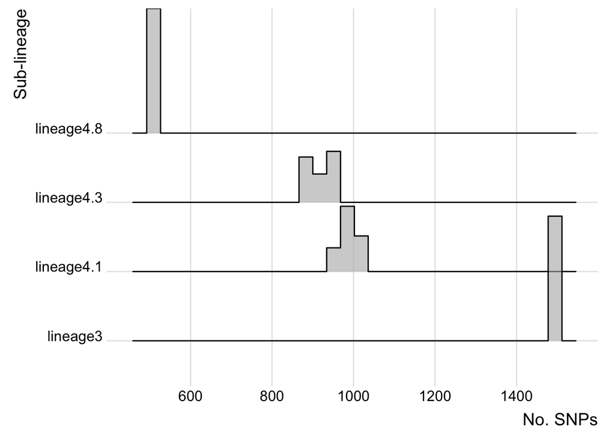

### RutiSeq-db

**78 genome(s) failed the minimum quality criteria** (see `Parameters`) and should be reviewed, and **5 genomes were identified as mixed infection(s)** (i.e., containing multiple lineages). These are highlighted in the `Failed QC` tab.

In terms of antibiotic resistance, **1807 isolates were sensitive**, while **469 displayed resistance**. Resistant isolates are summarised in the `DRTypes (WHO)` and `Resistance (WHO)` tabs.

**Main lineages**

[interactive chart not shown]

**Sub-lineages**

[interactive chart not shown]

**DRTypes (WHO)**

[interactive chart not shown]

**Resistance (WHO)**

[interactive chart not shown]

**Failed QC**

If this table is empty, then great! All your samples in the RutiSeq/db pass the quality metrics defined when you ran the RutiSeq workflow. Any failed variables will be colored in red.

|  | Sample | Total Reads | Unambiguous Total Bases (%) | Unambiguous Coverage median | Infection type | Lineages (fractions) |
| --- | --- | --- | --- | --- | --- | --- |
| 1 | 51-070_R005 | 4024389 | 0.72 | 14 | Clonal | L4.8 (100%) |
| 2 | 08-093_R010 | 3436303 | 0.95 | 24 | Clonal | L4.1.2.1 (99.6%) |
| 3 | 47-195_L29 | 1033471 | 0.96 | 25 | Clonal | L4.3.4.2 (100%) |
| 4 | 29-217_R001 | 1251271 | 0.98 | 33 | Clonal | L4.3.2 (100%) |
| 5 | 20-170_R007 | 1330063 | 0.98 | 35 | Clonal | L4.3.2 (100%) |
| 6 | 03-022_R010 | 1830549 | 0.99 | 40 | Clonal | L3.1.2.1 (96.5%) |
| 7 | 29-217_R010 | 1956301 | 0.99 | 42 | Clonal | L4.3.2 (100%) |
| 8 | 32-094_R001 | 1426226 | 0.98 | 43 | Clonal | L3 (100%) |
| 9 | 05-331_R001 | 1579095 | 0.98 | 44 | Clonal | L6.1.3 (100%) |
| 10 | 20-182_R007 | 1810182 | 0.99 | 44 | Clonal | L3.1.2.1 (94.8%) |

[output cut: 68 more lines]

**SNP freq (main)**

This tab features a ridge plot displaying multiple histograms that show the number of SNP variations identified between isolates belonging to each lineage and the reference genome (H37Rv). For clarity, isolate identified as a mixed infection have been removed. This is of value to understand the overall SNP frequencies of your dataset, and can be used to help identify samples that have suspicoiusly high or low number of SNPs (this can sometimes indicate there is something unusualy about the isolate - which can in turn cause issues with clustering)

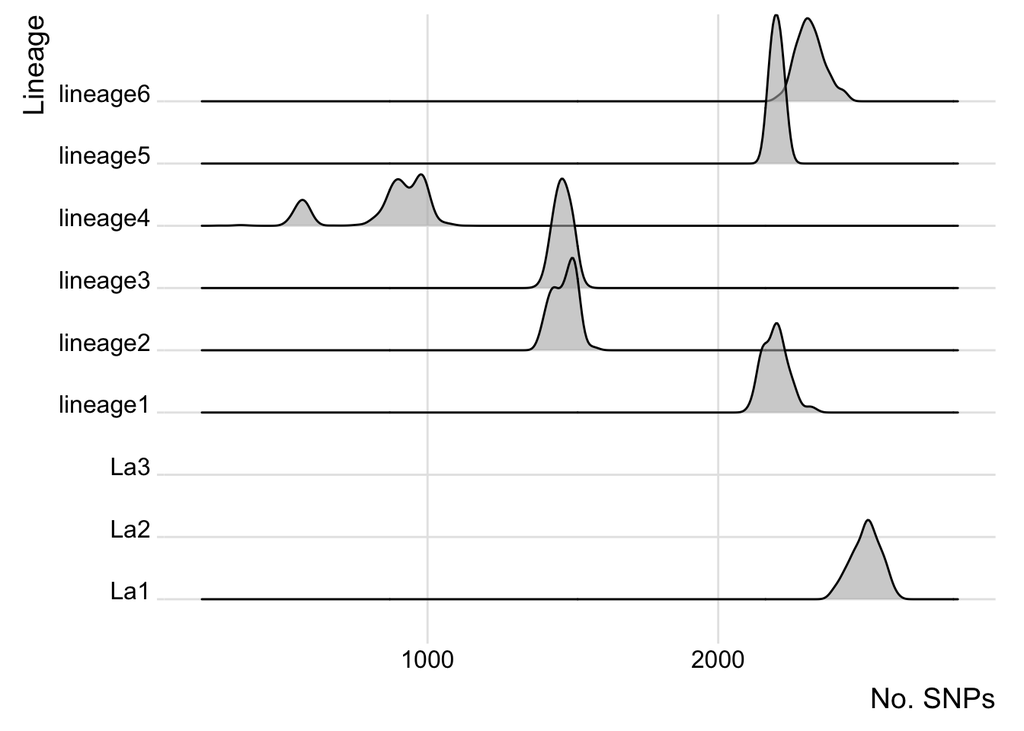

**SNP freq (sub)**

This tab features a ridge plot displaying multiple histograms that show the number of SNP variations identified between isolates belonging to each sub-lineage and the reference genome (H37Rv). For clarity, isolate identified as a mixed infection have been removed. This is of value to understand the overall SNP frequencies of your dataset, and can be used to help identify samples that have suspicoiusly high or low number of SNPs (this can sometimes indicate there is something unusualy about the isolate - which can in turn cause issues with clustering)

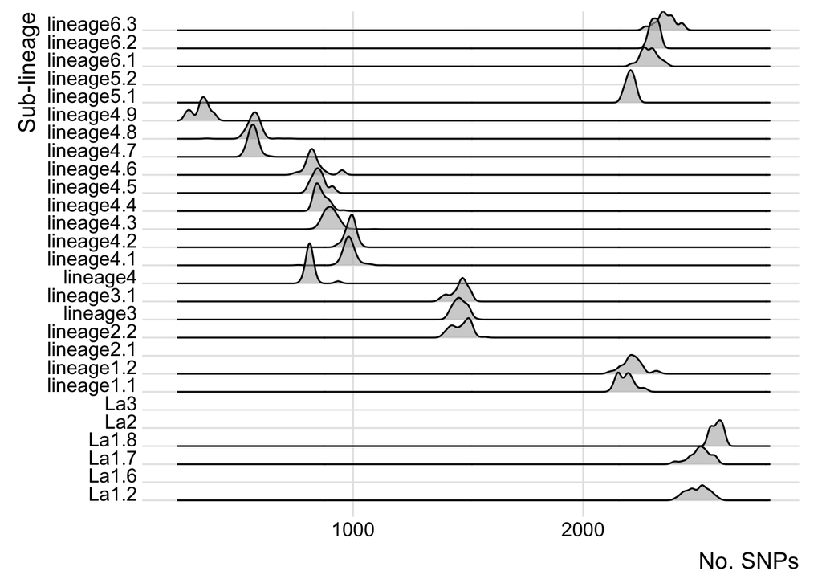

## Outbreak Clusters

This section presents the outbreak clusters identified using SNP threshold clustering, based on the defined thresholds (t=5, t=10, t=15). Cluster identifiers follow the format: `Cluster number`**–**`SNP distance`**–**`Lineage`.

> ⚠️ Cluster identifiers are not preserved across analyses. For accurate interpretation, avoid comparing cluster IDs between different reports. If consistency is required, consider exporting the cluster assignments and creating your own internal naming convention, or updating the cluster files to remain consistent with past cluster identifies. This feature may change in the future, but there are currently no plans to implement persistent clusterIDs.

**Clusters**

In this tab, a time series of clusters and their growth is displayed in the scatterplot. Use the slider to visualize the expansion of clusters over time. Each data point represents an outbreak cluster, colored by its lineage. For this plot, the lowest threshold is selected and only clusters larger than 3 cases.

[interactive chart not shown]

**Growing clusters**

In this tab, clusters identified within the RutiSeq-db that have grown with the addition of new cases are highlighted.

|  | SampleID | lineage | t=5 | t=10 | t=15 |
| --- | --- | --- | --- | --- | --- |
| 1 | 10-228_L2829 | lineage4.1 | 45-5-L4.1 | 49-10-L4.1 | 48-15-L4.1 |
| 2 | 10-238_L29 | lineage4.1 | 45-5-L4.1 | 49-10-L4.1 | 48-15-L4.1 |
| 3 | 04-172_R001 | lineage4.1 |  | 58-10-L4.1 | 60-15-L4.1 |
| 4 | 04-190_R007 | lineage4.1 |  | 58-10-L4.1 | 60-15-L4.1 |
| 5 | 32-085_L28 | lineage4.1 | 39-5-L4.1 | 59-10-L4.1 | 29-15-L4.1 |
| 6 | 32-086_R001 | lineage4.1 | 39-5-L4.1 | 59-10-L4.1 | 29-15-L4.1 |
| 7 | 32-087_R001 | lineage4.1 | 39-5-L4.1 | 59-10-L4.1 | 29-15-L4.1 |
| 8 | 08-073_L28 | lineage4.1 | 8-5-L4.1 | 70-10-L4.1 | 6-15-L4.1 |
| 9 | 10-201_L2529 | lineage4.1 | 8-5-L4.1 | 70-10-L4.1 | 6-15-L4.1 |
| 10 | 10-213_L26 | lineage4.1 | 8-5-L4.1 | 70-10-L4.1 | 6-15-L4.1 |

[output cut: 82 more lines]

**New clusters**

|  | SampleID | lineage | t=5 | t=10 | t=15 |
| --- | --- | --- | --- | --- | --- |
| 1 | 05-392_R001 | lineage4.3 | 33-5-L4.3 | 32-10-L4.3 | 31-15-L4.3 |
| 2 | 05-393_R001 | lineage4.3 | 33-5-L4.3 | 32-10-L4.3 | 31-15-L4.3 |

### Table of clusters

|  | SampleID | lineage | t=5 | t=10 | t=15 |
| --- | --- | --- | --- | --- | --- |
| 1 | 08-096_R007 | La1 | 1-5-La1 | 1-10-La1 | 1-15-La1 |
| 2 | 10-236_R001 | La1 | 1-5-La1 | 1-10-La1 | 1-15-La1 |
| 3 | 51-056_L28 | La1 | 1-5-La1 | 1-10-La1 | 1-15-La1 |
| 4 | 03-023_R010 | La1 | 2-5-La1 | 2-10-La1 | 1-15-La1 |
| 5 | 03-024_R010 | La1 | 2-5-La1 | 2-10-La1 | 1-15-La1 |
| 6 | 05-012_L1 | La1 | 2-5-La1 | 2-10-La1 | 1-15-La1 |
| 7 | 05-053_L2 | La1 | 2-5-La1 | 2-10-La1 | 1-15-La1 |
| 8 | 05-398_L29 | La1 | 2-5-La1 | 2-10-La1 | 1-15-La1 |
| 9 | 05-404_R007 | La1 | 2-5-La1 | 2-10-La1 | 1-15-La1 |
| 10 | 14-049_L2 | La1 | 2-5-La1 | 2-10-La1 | 1-15-La1 |

[output cut: 882 more lines]

# RutiSeq-db

Below is an interactive table of the entire RutiSeq-db for browsering. This includes all the antimicrobial resistance genes, resistanceprofiles, cluster memebership and general mapping statistics to the reference genome.

|  | Sample | Library | Main lineage | Sub-lineage | DR type (WHO) | DR type (corr WHO) | DR type (ext corr WHO) | Total Reads | Unambiguous Total Bases | Unambiguous Total Bases (%) | Unambiguous GC Content | Unambiguous Coverage median | nSNPs | Infection type | Lineages (fractions) | Lineages (mixed fractions >90%) | t=5 | t=10 | t=15 |
| --- | --- | --- | --- | --- | --- | --- | --- | --- | --- | --- | --- | --- | --- | --- | --- | --- | --- | --- | --- |
| 1 | 51-070_R005 | R005 | lineage4 | lineage4.8 | Other | Poly-DR TB | Poly-DR (FQ) | 4024389 | 3192852 | 0.72 | 65.89 | 14 | 359 | Clonal | L4.8 (100%) |  |  |  |  |
| 2 | 08-093_R010 | R010 | lineage4 | lineage4.1.2.1 | HR-TB | Mono-DR TB | Mono-DR (INH) | 3436303 | 4201693 | 0.95 | 65.5 | 24 | 924 | Clonal | L4.1.2.1 (99.6%) |  |  |  |  |
| 3 | 47-195_L29 | L29 | lineage4 | lineage4.3.4.2 | Sensitive | Sensitive TB | Sensitive | 1033471 | 4225148 | 0.96 | 65.53 | 25 | 865 | Clonal | L4.3.4.2 (100%) |  |  |  |  |
| 4 | 29-217_R001 | R001 | lineage4 | lineage4.3.2 | Sensitive | Sensitive TB | Sensitive | 1251271 | 4341536 | 0.98 | 65.53 | 33 | 859 | Clonal | L4.3.2 (100%) |  | 57-5-L4.3 | 1-10-L4.3 | 1-15-L4.3 |
| 5 | 20-170_R007 | R007 | lineage4 | lineage4.3.2 | Sensitive | Sensitive TB | Sensitive | 1330063 | 4343455 | 0.98 | 65.54 | 35 | 876 | Clonal | L4.3.2 (100%) |  | 57-5-L4.3 | 1-10-L4.3 | 1-15-L4.3 |
| 6 | 03-022_R010 | R010 | lineage3 | lineage3.1.2.1 | Other | Mono-DR TB | Mono-DR (STM) | 1830549 | 4360682 | 0.99 | 65.55 | 40 | 1488 | Clonal | L3.1.2.1 (96.5%) |  |  |  |  |
| 7 | 29-217_R010 | R010 | lineage4 | lineage4.3.2 | Sensitive | Sensitive TB | Sensitive | 1956301 | 4356694 | 0.99 | 65.54 | 42 | 882 | Clonal | L4.3.2 (100%) |  | 57-5-L4.3 | 1-10-L4.3 | 1-15-L4.3 |
| 8 | 32-094_R001 | R001 | lineage3 | lineage3 | Sensitive | Sensitive TB | Sensitive | 1426226 | 4321582 | 0.98 | 65.46 | 43 | 1412 | Clonal | L3 (100%) |  |  |  |  |
| 9 | 05-331_R001 | R001 | lineage6 | lineage6.1.3 | Sensitive | Sensitive TB | Sensitive | 1579095 | 4301760 | 0.98 | 65.46 | 44 | 2213 | Clonal | L6.1.3 (100%) |  |  |  |  |
| 10 | 20-182_R007 | R007 | lineage3 | lineage3.1.2.1 | HR-TB | Poly-DR TB | Poly-DR (INH+STM) | 1810182 | 4365221 | 0.99 | 65.55 | 44 | 1465 | Clonal | L3.1.2.1 (94.8%) |  |  |  |  |

[output cut: 2034 more lines]

# Methods

Reads were analysed using an custom workflow written with Nextflow, (RutiSeq-nf)[https://github.com/phesketh-igtp/RutiSeq-nf]. Raw FASTQ reads are taxonomically classified using Sylph v0.8.1 (microbial database, accessed 2025-06-02). Reads are analysed with *MTBseq v1.1.0* and *TB-Profiler v6.6.3*, which both perform referenced-based analysis using the virulent laboratory reference strain H37Rv (NC_000962) (Coll et al., 2014; Homolka et al., 2012; Kohl et al., 2018; Merker et al., 2015; Verboven et al., 2022). TB-Profiler classifies MTBC lineages and in silico drug-resistance profiling. TB-Profiler uses *Trimmomatic v0.39* (Bolger et al., 2014), BWA-mem v0.7.18 (Li & Durbin, 2009), and *freebayes v1.3.6* (Garrison & Marth, 2012) to perform adapter trimming, read mapping and variant calling respectively. Lineage classification was based on a 90-SNP barcode, while resistance profiles were derived using both WHO categorization (–db who), (The World Health Organisation, 2023).

Isolates are initially grouped by lineage (e.g. L1, L2, etc.). Lineage 4, the most abundant, was further subdivided into second-level sub-lineages (e.g. L4.1, L4.2, etc.) to reduce processing time. Lineage-grouped genomes are pairwise analysed using MTBseq functions (–step TBjoin, –step TBamend, and –step TBGroup), generating SNP distance matrices, and clustering at three distinct SNP distances (5, 10 and 15), and SNP multiple-sequence alignments for each (sub)-lineage. Maximum-likelihood trees (GTR+G4) were constructed from concatenated variable sites across lineage grouped genomes with *IQ-TREE v2.3.6* (Minh et al., 2020; Nguyen et al., 2015). Resulting trees were visualized and annotated with the R package *ggtree v3.14* (Yu et al., 2017). Trees were manually inspected to identify any non-monophyletic clusters. For each genomic cluster, SNP were identified from MTBseq concatenated SNP alignment files using *SNP-sites v2.5.1* (Page et al., 2016). Reference position for cluster SNPs were extracted also with SNP-sites, and two reference SNP profiles were reconstructed, H37Rv and MTBc ancestral genomes reconstructed using ancient DNA (Comas et al., 2013). Resulting SNP alignments were converted to NEXUS format using seqret part of the Emboss v6.6.0 suit of tools (Rice et al., 2000).

## Parameters

The analysis parameters used in the workflow are summarized below, in addition to the default values.

| **Category** | Value |
| --- | --- |
| **Run ID** | default_run |
| **Total cases** | 2277 |
| **New cases** | 19 |
| **SNP distance thresholds** | t=5, t=10, t=15 (*default: 5, 10, 15*) |
| **Minimum Coverage (X)** | 50 X (*default: 50 X*) |
| **Minimum Coverage (%)** | 98 % (*default: 95 %*) |
| **Minimum Reads** | 500,000 (*default: 500,000*) |
| **IQ-TREE - no. bootstraps** | 1000 |
| **IQ-TREE - model** | GTR+G4 |
| **MTBSeq - minbqual** | 20 (*default: 13*) |
| **MTBSeq - mincovf** | 4 (*default: 4*) |
| **MTBSeq - mincovr** | 4 (*default: 4*) |
| **MTBSeq - minphred20** | 4 (*default: 4*) |
| **MTBSeq - minfreq** | 75 (*default: 75*) |
| **MTBSeq - unambig** | 95 (*default: 95*) |
| **MTBSeq - window** | 12 (*default: 12*) |

## References

Bolger, A. M., Lohse, M., & Usadel, B. (2014). *Trimmomatic: A Flexible Trimmer for Illumina Sequence Data*. Bioinformatics, 30(15), 2114–2120. https://doi.org/10.1093/bioinformatics/btu170

Coll, F., McNerney, R., Guerra-Assunção, J. A., Glynn, J. R., Perdigão, J., Viveiros, M., Portugal, I., Pain, A., Martin, N., & Clark, T. G. (2014). *A Robust SNP Barcode for Typing Mycobacterium Tuberculosis Complex Strains*. Nature Communications, 5(1), 4812. https://doi.org/10.1038/ncomms5812

Comas, I., Coscolla, M., Luo, T., Borrell, S., Holt, K. E., Kato-Maeda, M., Parkhill, J., Malla, B., Berg, S., Thwaites, G., Yeboah-Manu, D., Bothamley, G., Mei, J., Wei, L., Bentley, S., Harris, S. R., Niemann, S., Diel, R., Aseffa, A., … Gagneux, S. (2013). *Out-of-Africa Migration and Neolithic Coexpansion of Mycobacterium Tuberculosis with Modern Humans*. Nature Genetics, 45(10), 1176–1182. https://doi.org/10.1038/ng.2744

Danecek, P., Bonfield, J. K., Liddle, J., Marshall, J., Ohan, V., Pollard, M. O., Whitwham, A., Keane, T., McCarthy, S. A., Davies, R. M., & Li, H. (2021). *Twelve Years of SAMtools and BCFtools*. GigaScience, 10(2), giab008. https://doi.org/10.1093/gigascience/giab008

Garrison, E., & Marth, G. (2012). *Haplotype-based variant detection from short-read sequencing*. https://arxiv.org/abs/1207.3907v2

Homolka, S., Projahn, M., Feuerriegel, S., Ubben, T., Diel, R., Nübel, U., & Niemann, S. (2012). *High Resolution Discrimination of Clinical Mycobacterium tuberculosis Complex Strains Based on Single Nucleotide Polymorphisms*. PLOS ONE, 7(7), e39855. https://doi.org/10.1371/JOURNAL.PONE.0039855

Kohl, T. A., Utpatel, C., Schleusener, V., Filippo, M. R. De, Beckert, P., Cirillo, D. M., & Niemann, S. (2018). *MTBseq: A Comprehensive Pipeline for Whole Genome Sequence Analysis of Mycobacterium Tuberculosis Complex Isolates*. PeerJ, 6, e5895. https://doi.org/10.7717/peerj.5895

Li, H., & Durbin, R. (2009). *Fast and Accurate Short Read Alignment with Burrows-Wheeler Transform*. Bioinformatics (Oxford, England), 25(14), 1754–1760. https://doi.org/10.1093/bioinformatics/btp324

McKenna, A., Hanna, M., Banks, E., Sivachenko, A., Cibulskis, K., Kernytsky, A., Garimella, K., Altshuler, D., Gabriel, S., Daly, M., & DePristo, M. A. (2010). *The Genome Analysis Toolkit: A MapReduce framework for analyzing next-generation DNA sequencing data*. Genome Research, 20(9), 1297–1303. https://doi.org/10.1101/GR.107524.110

Merker, M., Blin, C., Mona, S., Duforet-Frebourg, N., Lecher, S., Willery, E., Blum, M. G. B., Rüsch-Gerdes, S., Mokrousov, I., Aleksic, E., Allix-Béguec, C., Antierens, A., Augustynowicz-Kopeć, E., Ballif, M., Barletta, F., Beck, H. P., Barry, C. E., Bonnet, M., Borroni, E., … Wirth, T. (2015). *Evolutionary history and global spread of the Mycobacterium tuberculosis Beijing lineage*. Nature Genetics, 47(3), 242–249. https://doi.org/10.1038/NG.3195

Minh, B. Q., Schmidt, H. A., Chernomor, O., Schrempf, D., Woodhams, M. D., von Haeseler, A., & Lanfear, R. (2020). *IQ-TREE 2: New Models and Efficient Methods for Phylogenetic Inference in the Genomic Era*. Molecular Biology and Evolution, 37(5), 1530–1534. https://doi.org/10.1093/molbev/msaa015

Nguyen, L.-T., Schmidt, H. A., von Haeseler, A., & Minh, B. Q. (2015). *IQ-TREE: A Fast and Effective Stochastic Algorithm for Estimating Maximum-Likelihood Phylogenies*. Molecular Biology and Evolution, 32(1), 268–274. https://doi.org/10.1093/molbev/msu300

Page, A. J., Taylor, B., Delaney, A. J., Soares, J., Seemann, T., Keane, J. A., & Harris, S. R. (2016). *SNP-sites: Rapid Efficient Extraction of SNPs from Multi-FASTA Alignments*. Microbial Genomics, 2(4), e000056. https://doi.org/10.1099/mgen.0.000056

Rice, P., Longden, L., & Bleasby, A. (2000). *EMBOSS: the European Molecular Biology Open Software Suite*. Trends in Genetics : TIG, 16(6), 276–277. https://doi.org/10.1016/S0168-9525(00)02024-2

The World Health Organisation. (2023). *Catalogue of Mutations in Mycobacterium Tuberculosis Complex and Their Association with Drug Resistance : Second Edition*. World Health Organization.

Verboven, L., Phelan, J., Heupink, T. H., & Rie, A. Van. (2022). *TBProfiler for Automated Calling of the Association with Drug Resistance of Variants in Mycobacterium Tuberculosis*. PLOS ONE, 17(12), e0279644. https://doi.org/10.1371/journal.pone.0279644

Yu, G., Smith, D. K., Zhu, H., Guan, Y., & Lam, T. T.-Y. (2017). *ggtree: An r Package for Visualization and Annotation of Phylogenetic Trees with Their Covariates and Other Associated Data*. Methods in Ecology and Evolution, 8(1), 28–36. https://doi.org/10.1111/2041-210X.12628